# **Transaction Anomaly Detection**

## **Project Overview**

This project focuses on detecting anomalies in financial transactions using **Isolation Forest**, a machine learning algorithm for anomaly detection. The dataset contains details of transactions, including transaction amount, frequency, time of day, and user demographics.

### **Objective**

- Identify suspicious transactions that deviate significantly from normal behavior.
- Use **data visualization** and **machine learning** to classify anomalies.
- Implement an interactive system where users can input transaction details to check for anomalies.

```python
import pandas as pd
import plotly.express as px
from matplotlib import pyplot as plt
import seaborn as sns
from sklearn.model_selection import train_test_split
from sklearn.ensemble import IsolationForest
from sklearn.metrics import classification_report, confusion_matrix
from imblearn.over_sampling import SMOTE
import plotly.io as pio

# Comment the following line to change the default renderer
pio.renderers.default = "png"
```

## 1. Data Exploration

First, we load the dataset and explore its structure. This helps us understand the features and check for missing values.

```python
data = pd.read_csv("data/transaction_anomalies_dataset.csv")
data.head()
```

|  | Transaction_ID | Transaction_Amount | Transaction_Volume | Average_Transaction_Amount | Frequency_of_Transactions | Time_Since_Last_Transaction | Day_of_Week | Time_of_Day | Age | Gender | Income | Account_Type |
| --- | --- | --- | --- | --- | --- | --- | --- | --- | --- | --- | --- | --- |
| 0 | TX0 | 1024.835708 | 3 | 997.234714 | 12 | 29 | Friday | 06:00 | 36 | Male | 1436074 | Savings |
| 1 | TX1 | 1013.952065 | 4 | 1020.210306 | 7 | 22 | Friday | 01:00 | 41 | Female | 627069 | Savings |
| 2 | TX2 | 970.956093 | 1 | 989.496604 | 5 | 12 | Tuesday | 21:00 | 61 | Male | 786232 | Savings |
| 3 | TX3 | 1040.822254 | 2 | 969.522480 | 16 | 28 | Sunday | 14:00 | 61 | Male | 619030 | Savings |
| 4 | TX4 | 998.777241 | 1 | 1007.111026 | 7 | 7 | Friday | 08:00 | 56 | Female | 649457 | Savings |

```python
print(data.info())
```

```
<class 'pandas.core.frame.DataFrame'>
RangeIndex: 1000 entries, 0 to 999
Data columns (total 12 columns):
 #   Column                       Non-Null Count  Dtype
---  ------                       --------------  -----
 0   Transaction_ID               1000 non-null   object
 1   Transaction_Amount           1000 non-null   float64
 2   Transaction_Volume           1000 non-null   int64
 3   Average_Transaction_Amount   1000 non-null   float64
 4   Frequency_of_Transactions    1000 non-null   int64
 5   Time_Since_Last_Transaction  1000 non-null   int64
 6   Day_of_Week                  1000 non-null   object
 7   Time_of_Day                  1000 non-null   object
 8   Age                          1000 non-null   int64
 9   Gender                       1000 non-null   object
 10  Income                       1000 non-null   int64
 11  Account_Type                 1000 non-null   object
dtypes: float64(2), int64(5), object(5)
memory usage: 93.9+ KB
None
```

```python
print(data.describe())
```

```
       Transaction_Amount  Transaction_Volume  Average_Transaction_Amount  \
count         1000.000000         1000.000000                 1000.000000
mean          1038.122511            2.498000                 1000.682506
std            283.580055            1.115006                   20.632334
min            849.024392            1.000000                  939.081423
25%            966.028796            1.000000                  986.800556
50%           1002.118678            3.000000                 1000.501902
75%           1033.143657            3.000000                 1015.155595
max           3227.459108            4.000000                 1073.154036

       Frequency_of_Transactions  Time_Since_Last_Transaction          Age  \
count                1000.000000                  1000.000000  1000.000000
mean                   12.078000                    15.341000    40.641000
std                     4.245225                     8.361258    13.819953
min                     5.000000                     1.000000    18.000000
25%                     8.000000                     8.000000    29.000000
50%                    12.000000                    16.000000    41.000000
75%                    16.000000                    22.000000    53.000000
max                    19.000000                    29.000000    64.000000

             Income
count  1.000000e+03
mean   8.948238e+05
std    3.453562e+05
min    3.001590e+05
25%    5.917308e+05
50%    8.876645e+05
75%    1.178102e+06
max    1.499670e+06
```

## 2. Data Visualization

We analyze the distribution of transaction amounts and their relationships with other features.

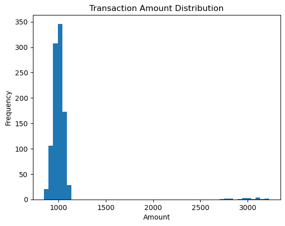

```python
plt.hist(data['Transaction_Amount'], bins=50)
plt.title('Transaction Amount Distribution')
plt.xlabel('Amount')
plt.ylabel('Frequency')
plt.show()
```

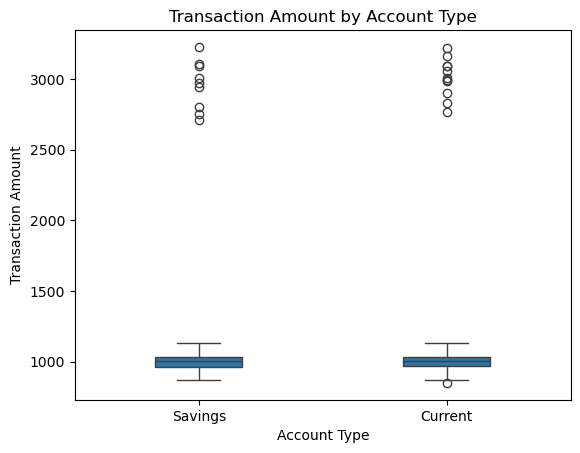

```python
sns.boxplot(y=data['Transaction_Amount'], x=data['Account_Type'], width=0.5, gap=0.3)
plt.xlabel('Account Type')
plt.ylabel('Transaction Amount')
plt.title('Transaction Amount by Account Type')
plt.show()
```

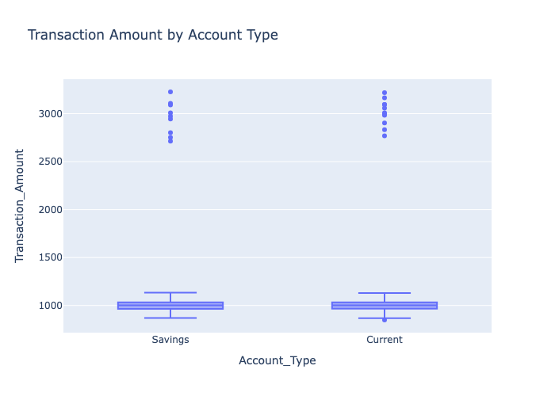

```python
# Transaction Amount by Account Type
fig_box_amount = px.box(data,
                        x='Account_Type',
                        y='Transaction_Amount',
                        title='Transaction Amount by Account Type')
fig_box_amount.show()
```

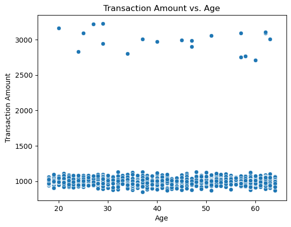

```python
# Average Transaction Amount vs. Age
sns.scatterplot(data=data, x='Age', y='Transaction_Amount')
plt.title('Transaction Amount vs. Age')
plt.xlabel('Age')
plt.ylabel('Transaction Amount')
plt.show()
```

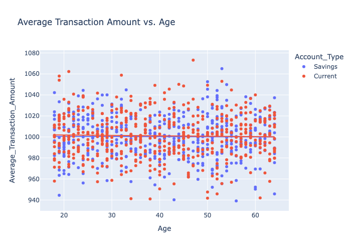

```python
# Average Transaction Amount vs. Age
fig_scatter_avg_amount_age = px.scatter(data, x='Age',
                                        y='Average_Transaction_Amount',
                                        color='Account_Type',
                                        title='Average Transaction Amount vs. Age',
                                        trendline='ols')
fig_scatter_avg_amount_age.show()
```

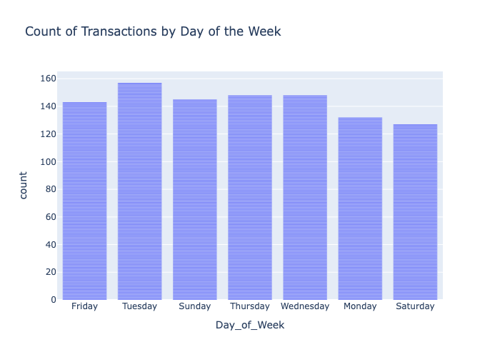

```python
# Count of Transactions by Day of the Week
fig_day_of_week = px.bar(data, x='Day_of_Week',
                         title='Count of Transactions by Day of the Week')
fig_day_of_week.show()
```

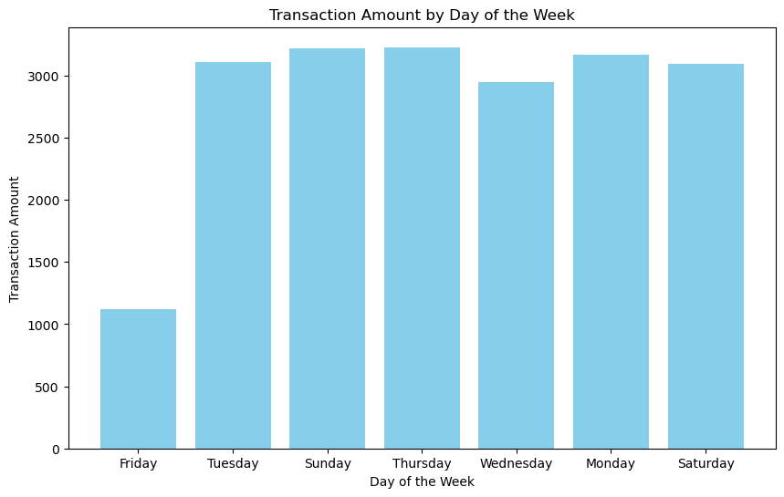

```python
plt.figure(figsize=(10, 6))
plt.bar(data['Day_of_Week'], height=data['Transaction_Amount'], color='skyblue')
plt.title('Transaction Amount by Day of the Week')
plt.xlabel('Day of the Week')
plt.ylabel('Transaction Amount')
plt.show()
```

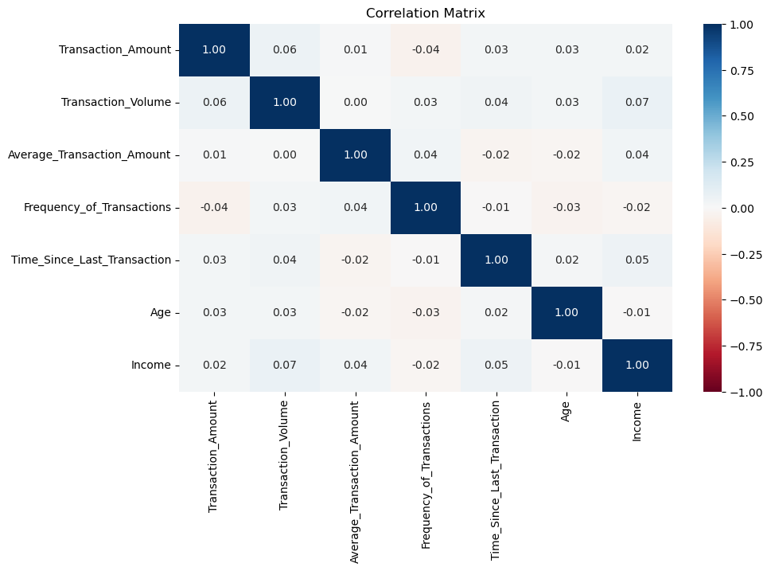

```python
correlation_matrix = data.select_dtypes(include='number').corr()

# PLot heatmap
plt.figure(figsize=(10, 6))
sns.heatmap(correlation_matrix, annot=True, cmap='RdBu', fmt='.2f', vmin=-1, vmax=1)
plt.title('Correlation Matrix')
plt.show()
```

## 3. Anomaly Detection

We define anomalies as transactions that exceed **two standard deviations** from the mean transaction amount.

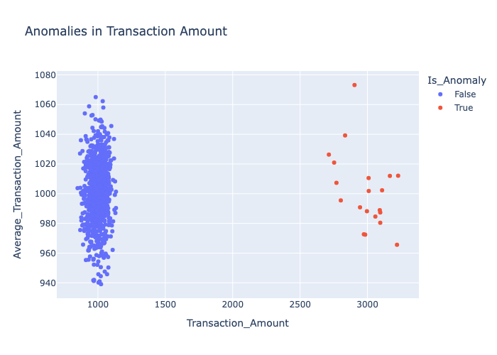

```python
# Calculate mean and standard deviation of Transaction Amount
mean_amount = data['Transaction_Amount'].mean()
std_amount = data['Transaction_Amount'].std()

# Define the anomaly threshold (2 standard deviations from the mean)
anomaly_threshold = mean_amount + 2 * std_amount

# Flag anomalies
data['Is_Anomaly'] = data['Transaction_Amount'] > anomaly_threshold

# Scatter plot of Transaction Amount with anomalies highlighted
fig_anomalies = px.scatter(data, x='Transaction_Amount', y='Average_Transaction_Amount',
                           color='Is_Anomaly', title='Anomalies in Transaction Amount')
fig_anomalies.update_traces(marker=dict(size=12),
                            selector=dict(mode='markers', marker_size=1))
fig_anomalies.show()
```

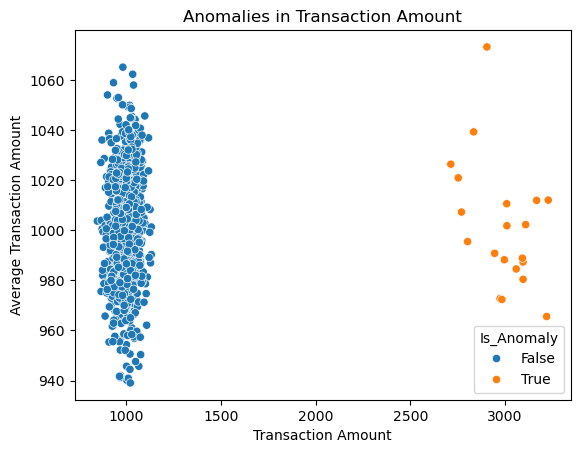

```python
sns.scatterplot(x=data['Transaction_Amount'], y = data['Average_Transaction_Amount'], hue=data['Is_Anomaly'])
plt.title('Anomalies in Transaction Amount')
plt.xlabel('Transaction Amount')
plt.ylabel('Average Transaction Amount')
plt.show()
```

```python
# Calculate the number of anomalies
num_anomalies = data['Is_Anomaly'].sum()

# Calculate the total number of instances in the dataset
total_instances = data.shape[0]

# Calculate the ratio of anomalies
anomaly_ratio = num_anomalies / total_instances

print(f'Number of anomalies: {num_anomalies}')
print(f'% of anomalies in the data: {anomaly_ratio:.2%}')
```

```
Number of anomalies: 20
% of anomalies in the data: 2.00%
```

## 4. Model Training (Isolation Forest)

We use **Isolation Forest** to detect anomalies. Before training, we balance the dataset using **SMOTE**.

```python
relevant_features = ['Transaction_Amount',
                     'Average_Transaction_Amount',
                     'Frequency_of_Transactions']

# Split data into features (X) and target variable (y)
X = data[relevant_features]
y = data['Is_Anomaly']

# Split data into train and test sets
X_train, X_test, y_train, y_test = train_test_split(X, y, test_size=0.2, random_state=42)

smote = SMOTE(sampling_strategy=0.1, random_state=42)  # Increase anomalies to 10%
X_train_balanced, y_train_balanced = smote.fit_resample(X_train, y_train)

# Train the Isolation Forest model
model = IsolationForest(contamination=0.05, random_state=42)
model.fit(X_train_balanced)
```

```
IsolationForest(contamination=0.05, random_state=42)
```

## 5. Model Evaluation

```python
# Predict anomalies on the test set
y_pred = model.predict(X_test)

# Convert predictions to binary values (0: normal, 1: anomaly)
y_pred_binary = [1 if pred == -1 else 0 for pred in y_pred]

# Evaluate the model's performance
report = classification_report(y_test, y_pred_binary, target_names=['Normal', 'Anomaly'])
print(report)

# Print confusion matrix
conf_matrix = confusion_matrix(y_test, y_pred_binary)
print(conf_matrix)
```

```
              precision    recall  f1-score   support

      Normal       1.00      0.99      1.00       196
     Anomaly       0.80      1.00      0.89         4

    accuracy                           0.99       200
   macro avg       0.90      1.00      0.94       200
weighted avg       1.00      0.99      1.00       200

[[195   1]
 [  0   4]]
```

## 6. Interactive Anomaly Detection

Users can enter transaction details to check if their transaction is classified as an anomaly.

```python
# Relevant features used during training
relevant_features = ['Transaction_Amount', 'Average_Transaction_Amount', 'Frequency_of_Transactions']

# Get user inputs for features
user_inputs = []
for feature in relevant_features:
    user_input = float(input(f"Enter the value for '{feature}': "))
    user_inputs.append(user_input)

print("User Inputs:")
for feature, value in zip(relevant_features, user_inputs):
    print(f"  {feature}: {value}")

# Create a DataFrame from user inputs
user_df = pd.DataFrame([user_inputs], columns=relevant_features)

# Predict anomalies using the model
user_anomaly_pred = model.predict(user_df)

# Convert the prediction to binary value (0: normal, 1: anomaly)
user_anomaly_pred_binary = 1 if user_anomaly_pred == -1 else 0

if user_anomaly_pred_binary == 1:
    print("\nAnomaly detected: This transaction is flagged as an anomaly.")
else:
    print("\nNo anomaly detected: This transaction is normal.")
```

```
User Inputs:
  Transaction_Amount: 45000.0
  Average_Transaction_Amount: 2500.0
  Frequency_of_Transactions: 30.0

Anomaly detected: This transaction is flagged as an anomaly.
```